# Explore Difference in Number of Hazard Days for a Year

Benedito Chou

2019-04-19

## Setup Library

Install these packages if neccessary.

```r
library(readr)
library(gamlss)
library(tidyr)
library(knitr)
library(DT)
library(dplyr)
library(stringr)
library(scales)
library(broom)
library(ggplot2)
library(ggbeeswarm)
library(MASS)
library(pscl)
library(boot)
library(nlme)
library(cplm)
```

## Data Preparation

### Load Data

Load the data imported, processed and saved from “data wrangle change score centroid and map data.R”.

```r
load("processed_data v4.RData")
```

### Prepare Data

Keep distinct records within each time point only because keeping all pairwise records will inflate the number of observations in time 1 and 2.

```r
data_long <- distinct(merged_data_record_all_long, tribe, time, FIPS, .keep_all = TRUE)
```

Create data.frame to include only tribes with time 1 and 2 data.

```r
data_t1and2_long <- filter(data_long, tribe %in% tribes_time1and2_lst$tribe)
```

Convert time and tribe to factor for statistical modeling

```r
data_long <- data_long %>%
  ungroup() %>%
  mutate(tribe = factor(tribe),
         time = factor(time))

data_t1and2_long <- data_t1and2_long %>%
  ungroup() %>%
  mutate(tribe = factor(tribe),
         time = factor(time))
```

**Check Data**

First, confirm the data is correct, each tribe should have 2 summarized records in total, one for time 1 and one for time 2, so the resulted data.frame should has 0 row.

```r
t1and2_lst <- group_by(data_t1and2_long, tribe, time) %>%
  count() %>%
  ungroup() %>%
  group_by(tribe) %>%
  count() %>%
  filter(n < 2)

nrow(t1and2_lst)
```

```
## [1] 0
```

## Exploratory Analyses

### All Tribes, including those with time 1 or time 2 data only

### Plot Number of Hazard Days for a Year by Time

- The distribution of number of hazard days for a year in time 1 and time 2 is skewed to the left.
- The distirbution of number of hazard days for a year is about the same between time 1 and 2.

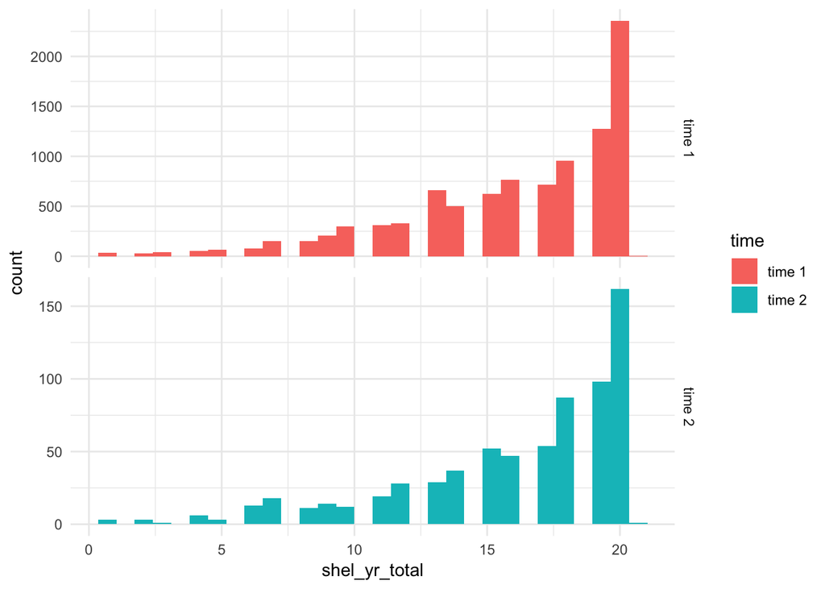

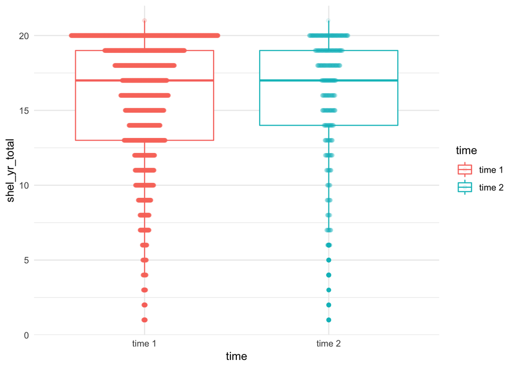

### Tribes with both time 1 or time 2 data

### Plot Number of Hazard Days for a Year by Time

- The distribution of number of hazard days for a year in time 1 and time 2 is skewed to the left.
- The distirbution of number of hazard days for a year is about the same in time 1 compared to time 2.

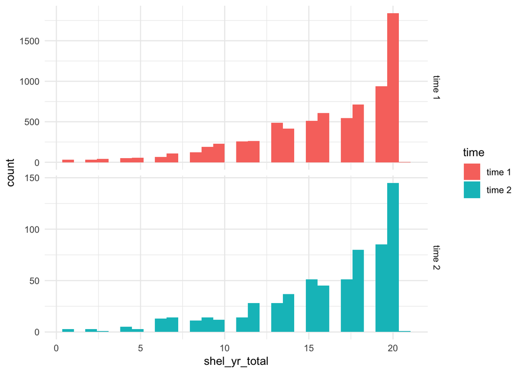

```r
ggplot(data_t1and2_long, aes(shel_yr_total, fill = time)) +
  facet_grid(rows = vars(time), scales = "free") +
  geom_histogram(position = "dodge", bin = 70) +
  theme_minimal()
```

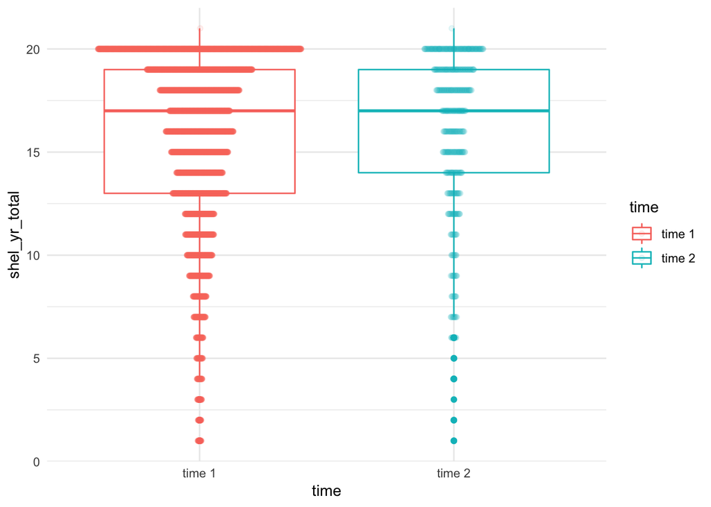

```r
ggplot(data_t1and2_long, aes(time, shel_yr_total, colour = time)) +
  geom_boxplot() +
  geom_quasirandom(alpha = 1/10, varwidth = TRUE) +
  theme_minimal()
```

### Plot relationship between Time 1 and Time 2 Number of Hazard Days for a Year at tribe level

- Compute the mean and median values of each tribe at time 1 and time 2. Look at the median as well as the mean because the median is a robust measure of central tendency and extreme-value resistent while the mean is heavily influenced by outliers.

#### Relationship between Time 1 and Time 2 Number of Hazard Days for a Year

- We found a large positive linear relationships between time 1 and time 2 number of hazard days for a year for mean (r = 0.7937) and for median (r = 0.7724)

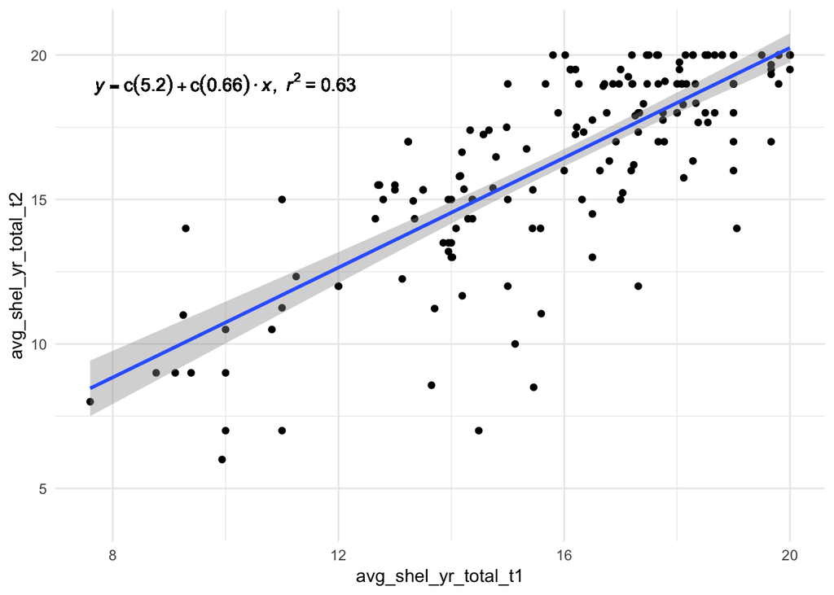

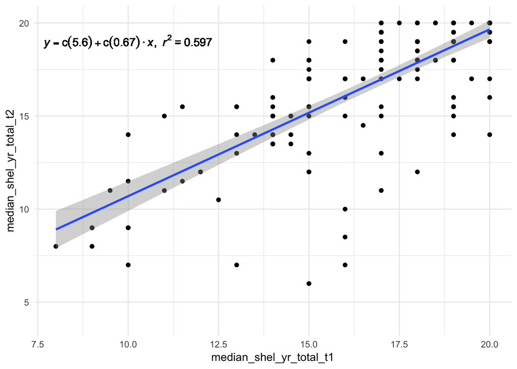

## Test for Significant Difference

### (1) Test for significant difference at the aggregate level

- We applied two statistical models - Linear Mixed Model and Repeated Measure ANOVA to examine statistical significant difference between Time 1 and Time 2 number of hazard days for a year.
- The models, as applicable, are run using all records from all tribes and tribes with both time 1 and 2 data.
- The model interpretation is based on the Linear Mixed Model. The Repeated Measure ANOVA results are shown for reference purposes.

### Use all records

Filter out NA outcomes

```r
model_data_long <- filter(data_long, !is.na(shel_yr_total))
model_data_t1and2_long <- filter(data_t1and2_long, !is.na(shel_yr_total))
```

### Repeated Measure ANOVA

- See Analysis below: Repeated Measure ANOVA can only be run with tribes with both time 1 and time 2 data.

### Linear Mixed Model

- Linear mixed model is a parametric test for comparing data when one or more of the independent variables should be model as a random effect because of variations by that variable.

```r
# Linear Mixed Model
lme_model <- nlme::lme(shel_yr_total ~ time, data = model_data_long, random = ~1|tribe)

summary(lme_model)
```

```
## Linear mixed-effects model fit by REML
##  Data: model_data_long
##        AIC      BIC    logLik
##   56636.21 56665.18 -28314.11
##
## Random effects:
##  Formula: ~1 | tribe
##         (Intercept) Residual
## StdDev:    2.391071 3.651637
##
## Fixed effects: shel_yr_total ~ time
##                 Value Std.Error   DF   t-value p-value
## (Intercept) 16.003988 0.1428725 9909 112.01592  0.0000
## timetime 2   0.219878 0.1550594 9909   1.41802  0.1562
##  Correlation:
##            (Intr)
## timetime 2 -0.147
##
## Standardized Within-Group Residuals:
##        Min         Q1        Med         Q3        Max
## -3.9795699 -0.5159167  0.2566560  0.6213371  2.7470025
##
## Number of Observations: 10308
## Number of Groups: 398
```

```r
anova(lme_model)
```

```
##             numDF denDF   F-value p-value
## (Intercept)     1  9909 12871.057  <.0001
## time            1  9909     2.011  0.1562
```

```r
model_para <- anova(lme_model)

mean_t1 <- round(mean(filter(data_long, time == "time 1")$shel_yr_total, na.rm = T), 3)
mean_t2 <- round(mean(filter(data_long, time == "time 2")$shel_yr_total, na.rm = T), 3)
sd_t1 <- round(sd(filter(data_long, time == "time 1")$shel_yr_total, na.rm = T), 3)
sd_t2 <- round(sd(filter(data_long, time == "time 2")$shel_yr_total, na.rm = T), 3)

pvalue <- round(model_para[2,4], 3)
Fvalue <- round(model_para[2,3], 3)
parameterdf1 <- round(model_para[2,1], 3)
parameterdf2 <- round(model_para[2,2], 3)
```

**Interpretation**

- At the aggregate level, the difference in number of hazard days for a year between time 1 (M = 15.994, SD = 4.116) and time 2 (M = 16, SD = 4.239) was not statistically signficant (F(1, 9909) = 2.011, p = 0.156).

### Use only records where tribes have time 1 and 2 data

### Repeated Measure ANOVA

- Repeated Measure ANOVA can only be run with tribes with both time 1 and time 2 data.

```r
# Repeated Measure ANOVA
aov_model <- aov(shel_yr_total ~ time + Error(tribe / time), data = model_data_t1and2_long)

summary(aov_model)
```

```
##
## Error: tribe
##            Df Sum Sq Mean Sq F value Pr(>F)
## time        1     28   28.11   0.164  0.686
## Residuals 182  31136  171.08
##
## Error: tribe:time
##            Df Sum Sq Mean Sq F value Pr(>F)
## time        1   13.2   13.21   0.871  0.352
## Residuals 183 2774.0   15.16
##
## Error: Within
##             Df Sum Sq Mean Sq F value Pr(>F)
## Residuals 7791 111595   14.32
```

```r
# Linear Mixed Model
lme_model <- nlme::lme(shel_yr_total ~ time, data = model_data_t1and2_long, random = ~1|tribe)

summary(lme_model)
```

```
## Linear mixed-effects model fit by REML
##  Data: model_data_t1and2_long
##        AIC      BIC    logLik
##   45292.04 45320.07 -22642.02
##
## Random effects:
##  Formula: ~1 | tribe
##         (Intercept) Residual
## StdDev:    2.333303 3.789115
##
## Fixed effects: shel_yr_total ~ time
##                 Value Std.Error   DF  t-value p-value
## (Intercept) 16.028868 0.1948040 7974 82.28205  0.0000
## timetime 2   0.225644 0.1645108 7974  1.37161  0.1702
##  Correlation:
##            (Intr)
## timetime 2 -0.155
##
## Standardized Within-Group Residuals:
##        Min         Q1        Med         Q3        Max
## -3.8361385 -0.5431345  0.2492909  0.6735402  2.6380463
##
## Number of Observations: 8159
## Number of Groups: 184
```

```r
anova(lme_model)
```

```
##             numDF denDF  F-value p-value
## (Intercept)     1  7974 6974.019  <.0001
## time            1  7974    1.881  0.1702
```

```r
model_para <- anova(lme_model)

mean_t1 <- round(mean(filter(data_t1and2_long, time == "time 1")$shel_yr_total, na.rm = T), 3)
mean_t2 <- round(mean(filter(data_t1and2_long, time == "time 2")$shel_yr_total, na.rm = T), 3)
sd_t1 <- round(sd(filter(data_t1and2_long, time == "time 1")$shel_yr_total, na.rm = T), 3)
sd_t2 <- round(sd(filter(data_t1and2_long, time == "time 2")$shel_yr_total, na.rm = T), 3)

pvalue <- round(model_para[2,4], 3)
Fvalue <- round(model_para[2,3], 3)
parameterdf1 <- round(model_para[2,1], 3)
parameterdf2 <- round(model_para[2,2], 3)
```

**Interpretation**

- At the aggregate level for tribes with migration, the difference in number of hazard days for a year area between time 1 (M = 15.864, SD = 4.224) and time 2 (M = 15.927, SD = 4.229) was not statistically signficant (F(1, 7974) = 1.881, p = 0.17).

### (2) Test for significant difference at tribe level

- At the tribe level, only repeated measure ANOVA is run because there is no random effect left in the model to run a mixed model - the varaible tribe that we allow to randomly vary is fixed at the tribe level.

```r
tribe_with_dif <- filter(merged_data_tribe, avg_shel_yr_total_change_score > 0) %>% group_by(tribe) %>% count()

no_test <- nrow(tribe_with_dif)
```

This can only be tested with the 184 tribes where migrations occured. Furthermore, only tribes where number of hazard days for a year have changed between time points and with more than one data point at each time point can their differences be tested for statistical significance. This reduce the number of tribes from 184 to 104.

### Run Repeated Measure ANOVA in Batch

- Run repeated measure ANOVA in batch using group_by and do at the tribe level.
- Include a try call to catch error.
- Use tidy from broom package to format the results into a data.frame.
- Replace NA estimate with all NA for that comparison.
- Filter out tribes where test cannot be run due to insufficient sample size.

Calculate number of test based only on tribes where there is non-zero difference and sufficient data point in number of hazard days for a year between time 1 and 2.

```r
no_test <- nrow(filter(model, !is.na(p.value)))
```

```r
model <- model %>%
  mutate(sig = ifelse(p.value < .05 / no_test, "yes", "no"))
```

- Add total number hazard of hazard days for a year for a county, distance, and no of unique FIPS to help with interpretation
- Rename some variables for prettier column headers

```r
results_df <- inner_join(model, merged_data_tribe, by = "tribe") %>%
  mutate(`Avg Diff No of Hazard Days` = avg_shel_yr_total_t2 - avg_shel_yr_total_t1) %>%
  dplyr::select(tribe, sig, p.value, `Avg Diff No of Hazard Days`, avg_shel_yr_total_t1, avg_shel_yr_total_t2, n_unique_FIPS_t1, n_unique_FIPS_t2, mid_dist) %>%
  arrange(p.value) %>%
  rename(
    `Avg No of Hazard Days T1` = avg_shel_yr_total_t1,
    `Avg No of Hazard Days T2` = avg_shel_yr_total_t2,
    `Unique FIPS T1` = n_unique_FIPS_t1,
    `Unique FIPS T2` = n_unique_FIPS_t2,
    `Mid Distance` = mid_dist)
```

### Results Table

#### Ordered by p value in ascending order

```r
datatable(results_df,
          filter = "top",
          options = list(pageLength = 20)) %>%
   formatRound(columns = c('p.value'), digits = 3) %>%
   formatRound(columns = c('Avg Diff No of Hazard Days', 'Avg No of Hazard Days T1', 'Avg No of Hazard Days T2', 'Mid Distance'), digits = 5)
```

|  | tribe | sig | p.value | Avg Diff No of Hazard Days | Avg No of Hazard Days T1 | Avg No of Hazard Days T2 | Unique FIPS T1 | Unique FIPS T2 | Mid Distance |
| --- | --- | --- | --- | --- | --- | --- | --- | --- | --- |
| 1 | Ottawa | no | 0.00180978000911608 | -1.18773946360153 | 17.1877394636015 | 16 | 261 | 4 | 193.333666069525 |
| 2 | Arapaho | no | 0.00340624218706223 | 2.44717444717445 | 14.1891891891892 | 16.6363636363636 | 115 | 11 | 424.433201446088 |
| 3 | Comanche | no | 0.00603771516553688 | 2.68085106382979 | 14.5691489361702 | 17.25 | 182 | 8 | 226.424169223378 |
| 4 | Kiowa | no | 0.00603771516553688 | 2.68085106382979 | 14.5691489361702 | 17.25 | 182 | 8 | 226.424169223378 |
| 5 | Modoc | no | 0.00837488043098793 | 4.70588235294118 | 9.29411764705882 | 14 | 12 | 2 | 1206.33091384627 |
| 6 | Chippewa | no | 0.0517329248502998 | -4.54390880723429 | 15.5926892950392 | 11.0487804878049 | 383 | 41 | 535.353093075632 |
| 7 | Apache | no | 0.0552561024498039 | 1.68221501621352 | 14.7914691943128 | 16.4736842105263 | 188 | 13 | 233.741039941687 |
| 8 | Miccosukee | no | 0.149600689928465 | 1.85074626865672 | 18.1492537313433 | 20 | 67 | 2 | 403.502428093726 |
| 9 | Walla Walla | no | 0.160517629313063 | 2.5 | 13 | 15.5 | 11 | 2 | 29.4833704440472 |
| 10 | Umatilla | no | 0.162347211729597 | 2.77272727272727 | 12.7272727272727 | 15.5 | 11 | 2 | 21.7219178978533 |

[output cut: 80 more lines]

```r
b_sig_tribe_lst <- filter(results_df, sig == "yes") %>%
  dplyr::select(tribe)
sig_tribe_lst <- filter(results_df, p.value < .05) %>%
  dplyr::select(tribe)
```

**Interpretation**

- The mean number of hazard days for a year comparisons for 0 tribes () achieve statistical significance when the Bonferroni correction is used.
- The tests have low statistical power to detect differences given the number of observations at time 2 is much smaller than time 1.
- If Bonferroni correction is not used, number of hazard days for a year was significantly differ between time 1 and 2 for 5 tribes :(Ottawa, Arapaho, Comanche, Kiowa, Modoc).
- Results with NA p values are from tribes where there isn’t sufficient data points in both time point to perform the planned statistical tests.

**Overall Interpretation**

- Overall, statistically significant difference were not found at the aggregate level when data for all tribes and tribes with migrations were analyzed on the outcome number of hazard days for a year.
- At the tribe level, when correction for multiple comparisons was made, number of hazard days for a year for 0 tribes were found to be statistically differ between time 1 and time 2.
- The lack of significant differences at the tribe level could be attributed to the low statistical power arises from the small number of observations at time 2. In some cases, there is only 1 data point in time 2 or time 1.